# Arbeidskrav våren 2022

MSB106, Anvendt by- og regionaløkonomi

Kevin Ha

Ola Andre Olofsson

Ann Elisabeth Jacobsen

Heidi Marie Rolfsnes

Daniel Karstad

Henriette Hansen

Susann Birkeland Sivertsen

Vilde Haugland

# Romlige forskjeller i næringsstruktur, virkninger av eksogene sjokk i basissysselsettingen, og lokale forskjeller I sysselsettingsvekst.

I denne oppgaven vil vi se på næringsstrukturer på Haugalandet, Sunnhordland og Hardanger.

Problemstillinger og beregninger vi vil se nærmere på

- Beskrive situasjonen slik den er for 2020, og for utviklingen over tid.
- Sysselsettingsutviklingen for ulike næringer i ulike kommuner og for regionen samlet.
- Andelen av sysselsettingen innenfor enkeltnæringer, og sammenligne situasjonen og utviklingen for lokale kommuner og lokal region med det som gjelder for nasjonen samlet.
- Beregne lokaliseringskvotienter for ulike næringer i ulike kommuner, og for regionen(e) samlet.
- Beregne ulike aggregeringsnivåer av næringer og geografi, identifiser mulige klynger basert på verdiene for lokaliseringskvotientene.
- Gjøre en vurdering av hvor konsentrert/spredt en næring er fordelt mellom kommunene i regionen, basert på beregninger av den romlige Gini-indeksen.
- Vurdere om sammenligningsgrunnlaget bør være samlet sysselsetting i regionen, eller samlet sysselsetting av nasjonen, og finne ut hvilken rolle det spiller om en bruker regionale eller nasjonale anslag for samlet sysselsetting.
- Finne ut om næringsstrukturen i regionen har blitt mer eller mindre diversifisert, mangfoldig, over tid.
- Beregne en regional mangfold-indeks og finne ut hvordan verdiene på en slik indeks er endret over tid.
- Vurdere om sysselsettingsandelene skal sammenlignes med nasjonale eller regionale andeler for de ulike næringene
- Gjenta beregninger for andeler av arbeidstakere i ulike næringer, lokaliseringskvotienter, den romlige Gini- koeffisienten og målet for mangfold av næringer, med utgangspunkt i data spesifisert etter arbeidstakernes bosted.
- Sammenligne resultatene for data etter arbeidssted, og kommenter hvilken informasjon resultatene gir om romlig mobilitet i arbeidsmarkedet.
- Gi en kort oversikt over pendlerstrømmer mellom kommunene i regionen
- Beregne og presentere andeler av arbeidstakere med bosted i en kommune som har arbeidssted i andre kommuner, og gjør det samme for andelen av jobbene i en kommune som er besatt av arbeidstakere fra andre kommuner.
- Diskutere forskjeller mellom kommunene i regionen, og drøft utviklingen over tid for ulike kommuner
- Beregne og presentere andelen av arbeidstakere som bor og jobber innenfor samme kommune. Se om det er systematiske forskjeller sett i forhold til sentralitet og tilgjengelighet i det lokale arbeidsmarkedet. Og om det er bestemte trender i utviklingen for ulike kommuner.
- Bruke beregningene av lokaliseringkvotienter til å dele næringene inn i lokal- og basisnæringer
- Formulere en økonomisk basemodell og beregne økonomiske basemuliplikatorer for enkeltkommuner og region(er).
- Vurdere lokale virkninger av alternative lokaliseringer i Odda, Husnes og Leirvik
- Drøfte virkninger av et slikt positivt eksogent sjokk for den lokale økonomien gjennom bruk av en basemodell
- Finne ut hvordan virkningene eventuelt spres til andre kommuner i regionen og hvordan en kan bruke data for pendlestrømmer til å predikere virkninger på sysselsettingen i ulike kommuner.
- Sammenligne disse prediksjonene med de vi får når vi gjennomfører analysen på regionalt nivå.
- Gi en shift-share analyse i en diskusjon av forskjeller i vekst for eksempel mellom indre, midtre og ytre deler av regionen, eller eventuelt områder/kommuner som har hatt sterk og svak befolkningsutvikling.

## Oversikt over befolkningene i regionene

### Haugalandet

Haugalandet består av kommunene Bokn (852), Haugesund (37357), Karmøy (42186), Sauda (4595), Tysvær(11065), Utsira(198) og Vindafjord(8714). tilsammen bor det 104967 personer i denne regionen. i tidsperioden vi har hentet inn data har det vert kommunesammenslåing i denne regionen. Da ble Ølen og vindafjord slått i sammen til en kommune (hvordan har vi tatt hensyn til dette???)

### Sunnhordland og Ullensvang

Sunnhordland og Ullensvang består av kommunene Bømlo(11957), Etne(4062), Fitjar(3189), Kvinnherad(13071), Stord(18759), Sveio(5766), Tysnes(2869) og Ullensvang(11048). Tilsammen bor det 70721 personer i denne regionen.

Tallene er hentet fra SSB 09.01.21 (https://www.ssb.no/statbank/table/01223/tableViewLayout1/) gjelder for 4 kvartal 2020.

# 1 Sysselsetting i ulike næringer, etter arbeidssted

**Antall personer som jobber i kommunen**

## Haugalandet

Første regionen vi velger å se på er Haugalandet. Her ønsker vi å se på utviklingen fra 2008 til 2020, av antall ansatte i sin helhet i regionen, samt de 6 mest relevante næringene.

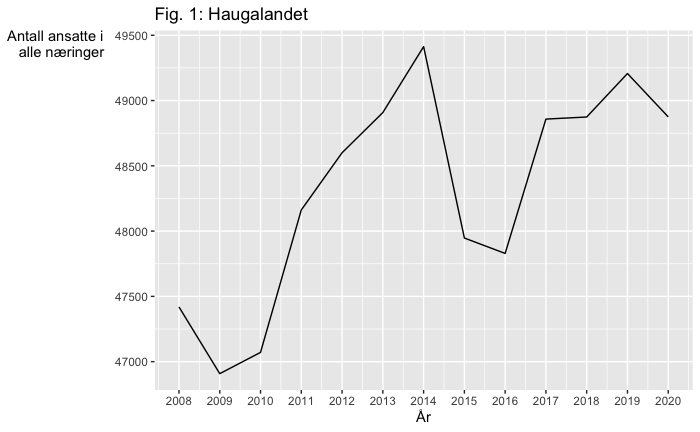

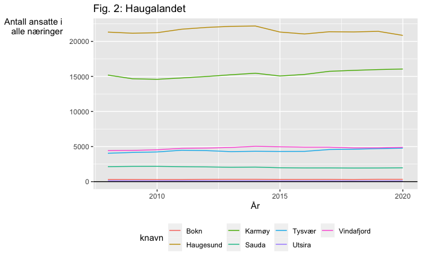

I Fig. 2 ser vi at flere av kommunene på Haugalandet har hatt liten arbeidsplassvekst, med unntak av Tysvær, Vindafjord og Karmøy i den siste tiårsperioden. Vi ser dette mer tydelig på fig. 3 og 4.

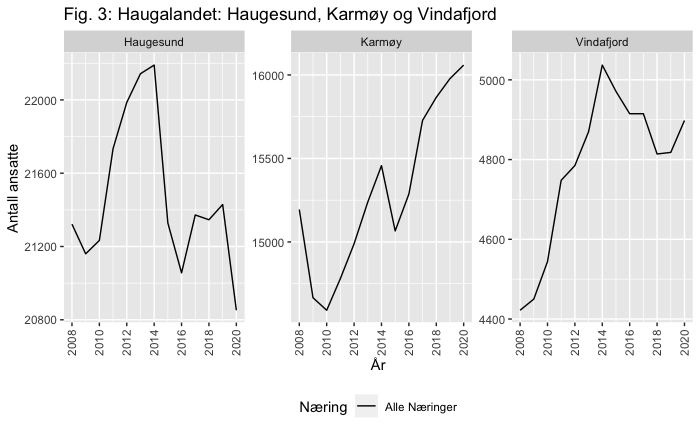

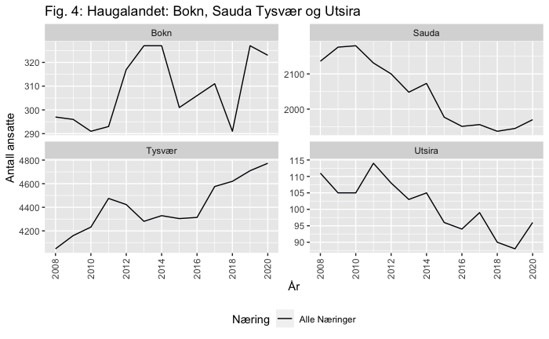

Figur 3 og 4 viser utviklingen av det totale antall ansatte i alle næringer på kommunalt nivå, innenfor Haugaland-regionen.

I disse figurene, så ser vi tydelig at Haugesund har hatt reduksjon i antall ansatte totalt sett, mens Karmøy, Vindafjord og Tysvær har hatt en markant vekst de siste ti årene. Siden Haugesund har flest arbeidsplasser betyr utviklingen i Haugesund mye for de samlede tallene.

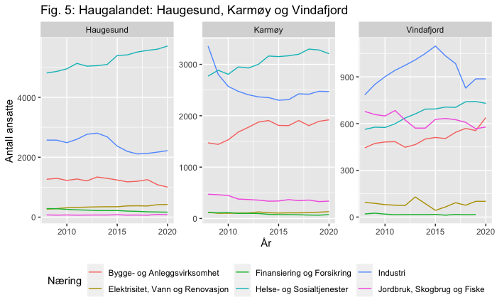

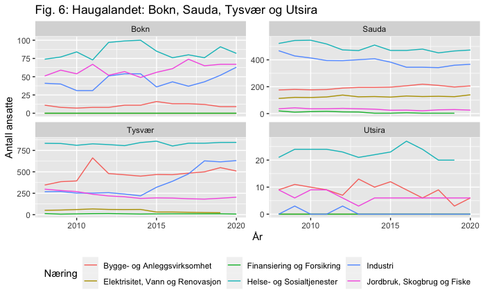

Figur 5 og 6 viser utviklingen av de 6 mest relevante næringene i Haugalandsregionen på kommune nivå.

Vi ser i de tre største kommunene, Haugesund, Karmøy og Vindafjord utgjør næringene Helse- og Sosialtjenester og Industri de største. Helse- og Sosialtjenester har vokst jevnt og trutt de siste tiårene, mens antall ansatte i industrinæringen har variert fra kommune til kommune. I Haugalandet utgjør primærnæringer (jordbruk, Skogbrug og Fiske) en større andel, enn hos Karmøy og Haugesund hvor primærnæringene kun utgjøre en liten andel.

### Sysselsettingsutviklingen for ulike næringer i ulike kommuner og for regionen samlet.

Det er relativt store kommunevise forskjeller i næringsstrukturen. Rogaland har en forholdsvis ensidig næringsstruktur, olje og gass er dominerende. Fylket er suverent dominerende for fossil energi. De har for øvrig de siste årene satset på et en mer differensiert næringsstruktur og næringsliv ved å satse på helse, IKT og fornybar energi.

I våre modeller, er satsingen på helse den mest tydelige. Av rent tekniske grunner er det vanskelig å se utviklingen i enkelte næringer som utgjør små andeler, på grunn av skalaen som er benyttet. Til tross for dette, kan man se at næringsstrukturen i regionen samlet generelt sett har endret seg lite.

Universitets- og høgskolesektoren er liten i Rogaland, og den består for det første av Universitetet i Stavanger (UiS) og Høgskulen på Vestlandet (HVL) med campus Haugesund.

Haugaland Vekst, som er eigd/drevet av Haugalandsregionen er i spissen på å legge til rette for å etablere ny industri samt andre arbeidsplasser i regionen.

I helsesektoren er Stavanger universitetssykehus (SuS) sentralt.

## Sunnhordland

Videre ønsker vi å se på den samme utviklingen, men denne gangen i Sunnhordlandsregionen.

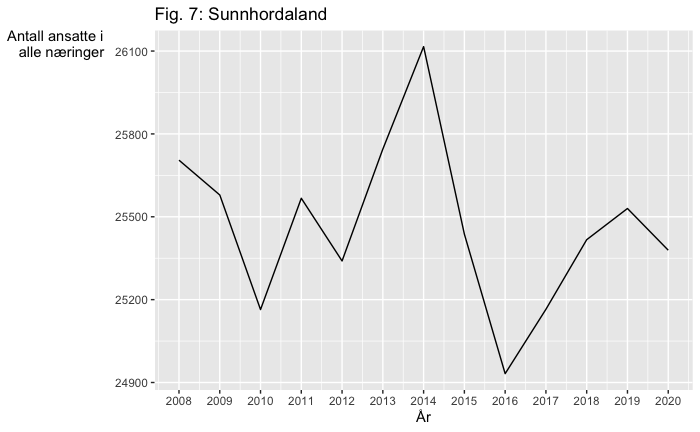

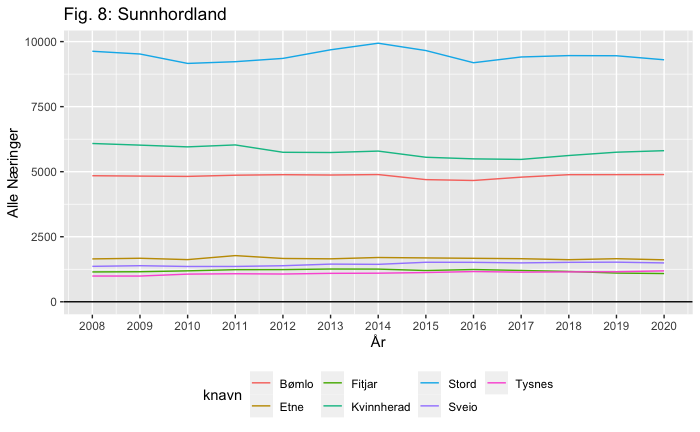

Figur 8 viser utviklingen av totalt ansatte i Sunnhordlandsregionen på kommunenivå i hele regionen fra 2008 til 2020. Denne figuren gir oss en oversikt, men er ikke heilt brukervennelig. Vi lager dermed en mer oversiktlig figur, jf. figur 9 & 10.

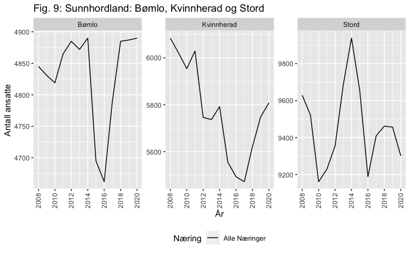

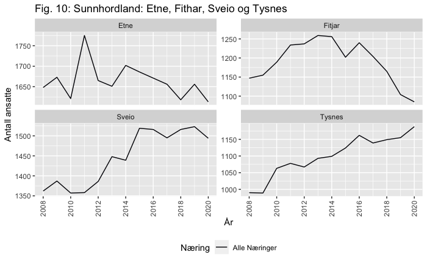

Vi ser her ut ifra figur 9 og 10 utviklingen for hver enkelt kommune i Sunnhordland totalt sett, og her ser vi mye tydligere utviklingen fra 2008 til 2020. En kan se her at Kvinnherad, Etne og Fitjar har hatt en reduksjon i totalt ansatte, mens Tysnes og Sveio har hatt ein kraftig vekst. En interessant bemerking er Stord i 2014 og Kvinnherad fra 2008 til 2017.

For å få et bedre oversikt over utviklingen i kommunen ønsker vi å se på de 6 mest relevante næringene i hver kommune.

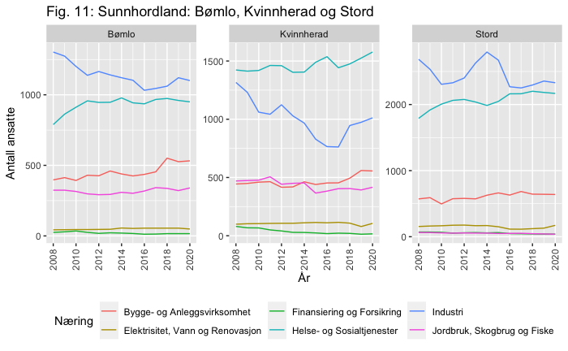

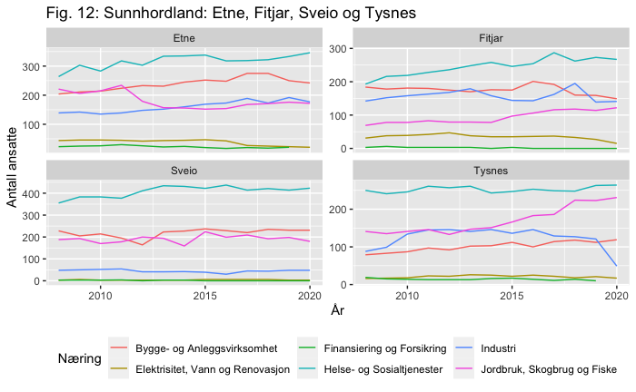

Figur 11 og 12 viser de 6 mest relevante næringene i hver enkelt kommune i Sunnhordlandsregionen fra 2008 til 2020.

### Sysselsettingsutviklingen for ulike næringer i ulike kommuner og for regionen samlet.

Det første bemerkelsesverdige i Sunnhordlandsregionen er den markante reduksjonen i industri i Stord kommune i 2014, samt Kvinnherad fra 2008. Dette stemmer overens med to hendelser. Den første er oljeknekken i 2014 som medførte at bl.a. Aker Stord AS som er avhengig av Olje-industrien måtte permitere.

Stord er en kommune som har mye offshore industri. I 2008/2009 så stengte Sør-Norge Aluminium “B-Hallen” som medførte 50% reduksjon i produksjon, og dermed ansatte. Interessant å bemerke at i Kvinnherad så er antall industriarbeidere redusert samtidig som antall ansatte i Helse- og Sosialetjenester økt. Bømlo har også sett en stabil reduksjon i ansatte innen industri, samt vekst i Helse- og Sosialetjenester frem til 2018.

## Hardanger

I henhold til oppgavens krav til betrakter vi *Hardanger* før 2019 som Ullensvang- og Odda kommune som to separerte kommuner. i 2020 så ble Ullensvang, Odda og Jondal slått sammen til Ullensvang. Dette forklarer den voldsomme økningen i sysselsetting i regionen ved tidspunktet for kommunesammenslåing.

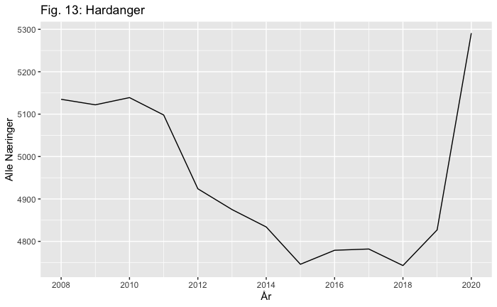

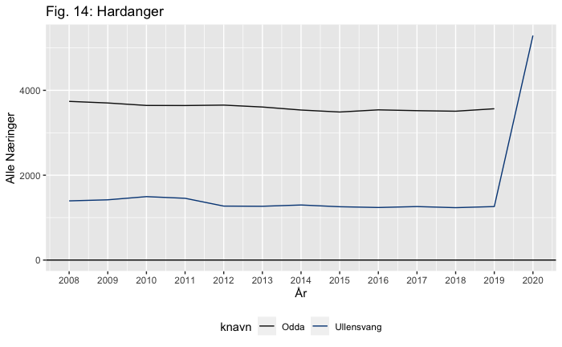

For å få en bedre oversikt over utviklingen innenfor de mest relevante næringene, så ser vi på figur 16.

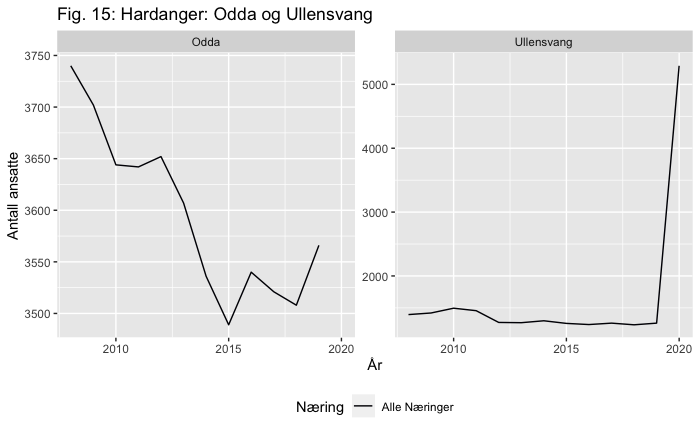

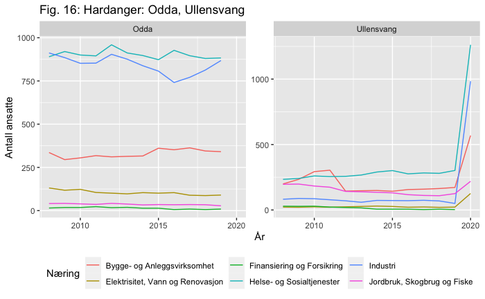

I figur 16 så ser en klart at det har vert en nedgang innen alle sektorer i Odda, med untakt av industri som har sett en vekst fra 2016 frem til 2019 før sammenslåingen. Ser videre at Ullensvang har hatt ein vekst innenfor Helse- og Sosialetjenester, men resten av sektorene har hatt en reduksjon helt fram til sammenslåingen i 2019.

Ullensvang kommune har stor kraftproduksjon og hovednæringen er industri. Majoriteten av kraftproduksjonen foregår i tidligere Odda. Odda er et ensidig industristed, men har også en maritim næring i tillegg. I figur 16 ser vi at industrinæringen utgjør en betraktelig større andel av sysselsettingen i her. Industrinæringen er også omfattet og bygg- og anleggsvirksomhet. På motsatt side er jordbruk, helse- og sosialtjenester dominerende i Ullensvang.

**Generelt om Ullensvang kommune**

Ullensvang kommune (med Odda) har hatt en jevn og negativ befolkningsvekst i mange tiår. Det gjenspeiles ikke tydelig i våre modeller på grunn av skalaen som er brukt. I tillegg har vi ikke hensyntatt innvandrende arbeidere, eller midlertidige fraflyttede som for eksempel studenter.

# 3 Sysselsetting i ulike næringer, etter bosted

**Hvor mange som bur i kommunen som jobber innenfor næring x**

Det neste vi ønsker å gjøre er å se bostedssituasjonen til arbeidstakere. Det vi ønsker å se på her da er hvor mange som jobber innenfor en sektor, f.eks. industri, som bor i regionen.

Den første regionen vi velger å se på i denne sammenhengen er Haugalandet.

## Haugalandet

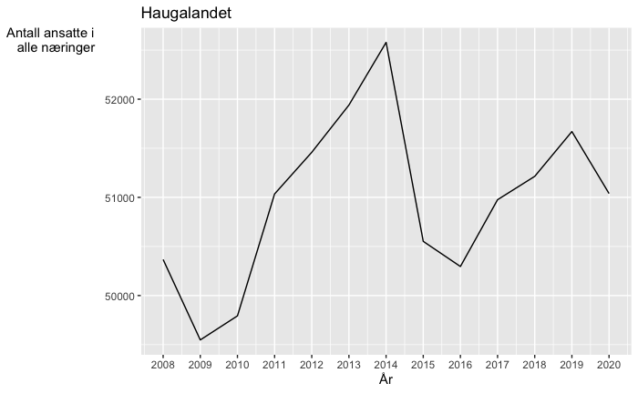

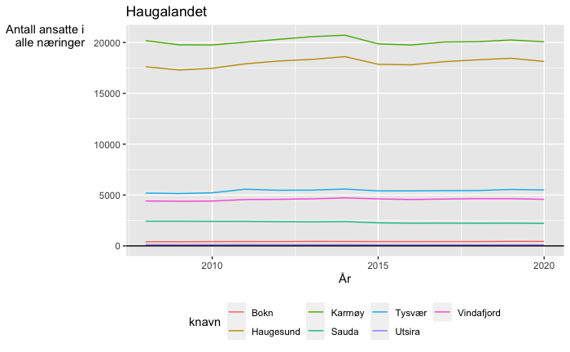

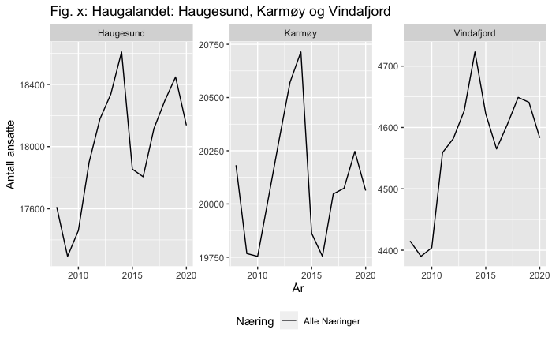

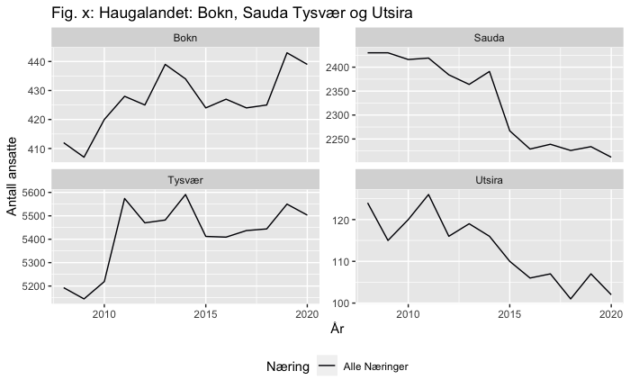

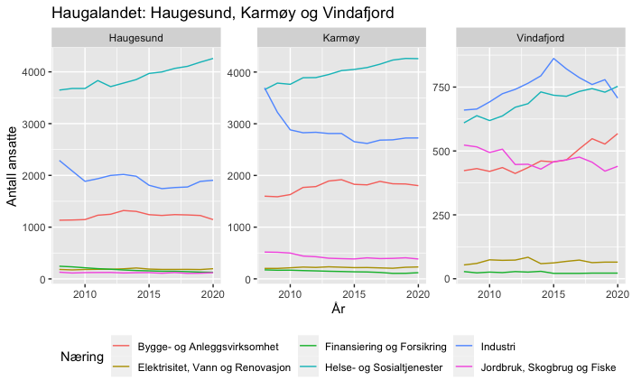

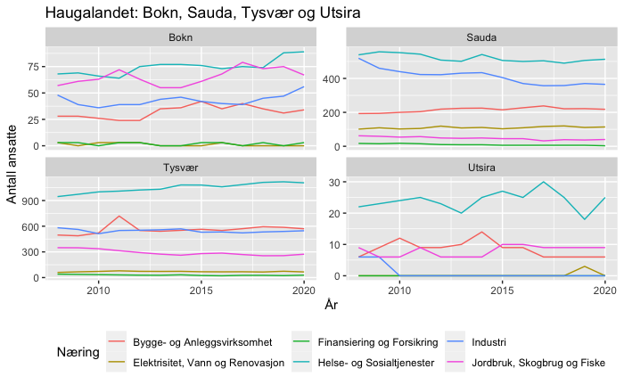

## Sunnhordland

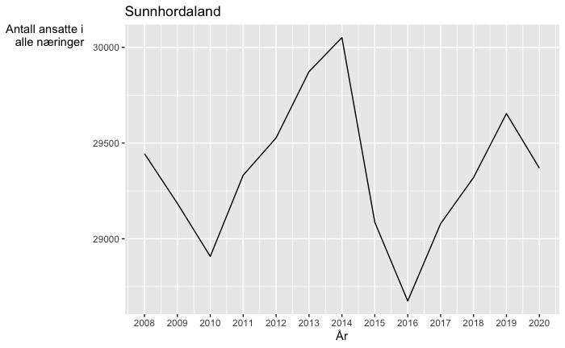

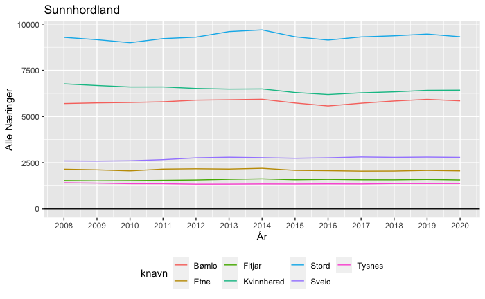

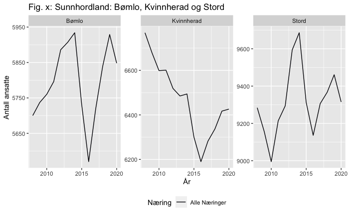

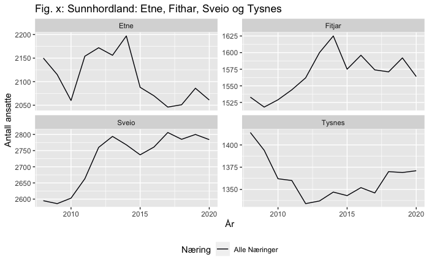

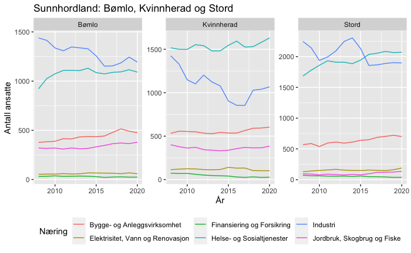

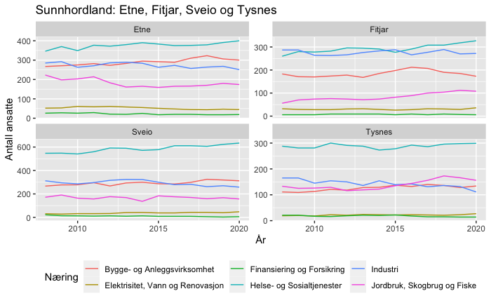

## Hardanger

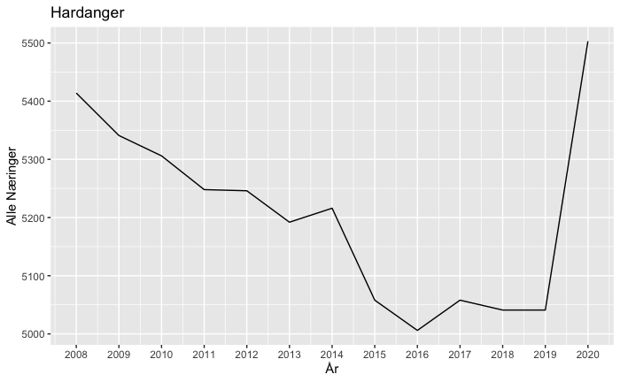

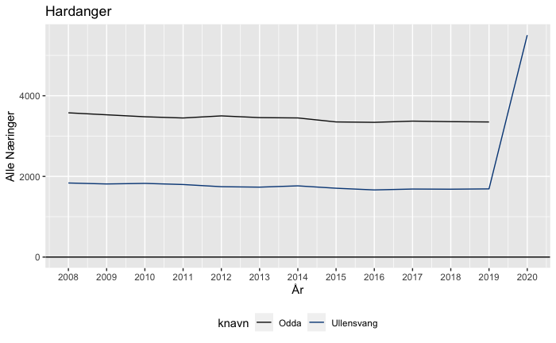

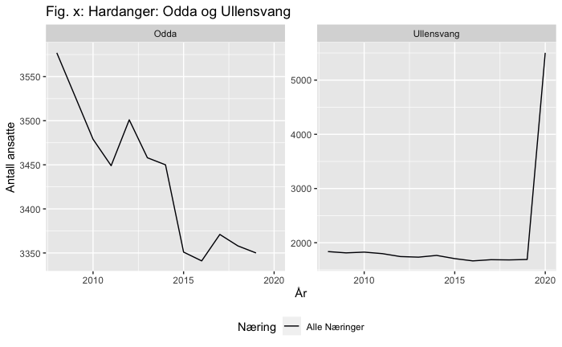

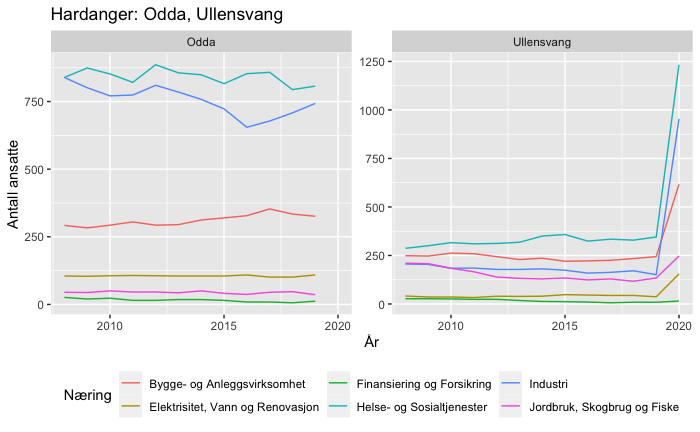

# Oppgave 4

Pendling er et viktig begrep å bruke når vi snakker om regional utvikling. De ulike kommunene eller regionene kan ha ulike behov. De aller fleste kommuner har for lite arbeidsplasser i forhold til antall arbeidene. Det vil si at de fleste plasser er de avhengige av å pendle til andre plasser. Det kan være andre kommuner i samme region eller andre regioner. Det finnes også begrepet netto innpendling som betyr at noen kommuner eller regioner har flere arbeidsplasser tilgjengelige enn de har folk til å jobbe der innad i kommunen. Vi skal se på innpendling og utpendling som vil kunne fortelle oss i hvilken grad et sted er integrert i et større arbeidsmarked https://regionalanalyse.no/rapport/3004/1/4.

Vi har laget en tabell som tar for seg regionen Haugalandet. Her kan vi skille de forskjellige kommunene og se hvor andelen av innpendling og utpendling er størst eller minst.

Vi kan se på Karmøy som et eksempel når det gjelder innpendling og utpendling. I Karmøy kommune er det 11637 stykk som jobber i egen kommune, mens 5888 pendler til andre kommuner i regionen. Herav pendler 4916 personer til Haugesund, 9 pendler til Sauda, 31 pendler til Bokn, 712 til Tysvær, 218 til Vindafjord og 2 personer pendler til Utsira. Når det kommer til innpendling kan vi se at det til sammen er 3384 som pendler til Karmøy fra Hauglandsregionen. Den største andelen fra samme region som pendler til Karmøy er Haugesund. Vi kan se fra tabellen at det er 2586 stykker som pendler fra Haugesund til Karmøy.

På Utsira som har en mindre befolkning ser vi at 85 jobber i hjemkommunen, mens 9 stk pendler til andre kommune i regionen, henholdsvis til Haugesund, Tysvær og Karmøy.

| Bokommuen | Haugesund_1106 | Sauda_1135 | Bokn_1145 | Tysvær_1146 | Karmøy_1149 | Utsira_1151 | Vindafjord_1160 |
| --- | --- | --- | --- | --- | --- | --- | --- |
| Haugesund_1106 | 11714 | 11 | 22 | 1029 | 2586 | 3 | 264 |
| Sauda_1135 | 31 | 1789 | 0 | 2 | 6 | 0 | 27 |
| Bokn_1145 | 50 | 0 | 223 | 41 | 41 | 0 | 16 |
| Tysvær_1146 | 1540 | 1 | 33 | 2270 | 645 | 0 | 267 |
| Karmøy_1149 | 4916 | 9 | 31 | 712 | 11637 | 2 | 218 |
| Utsira_1151 | 4 | 0 | 0 | 2 | 3 | 85 | 0 |
| Vindafjord_1160 | 306 | 10 | 1 | 238 | 103 | 0 | 3231 |

| Bokommuen | Etne_4611 | Sveio_4612 | Bømlo_4613 | Stord_4614 | Fitjar_4615 | Tysnes_4616 | Kvinnherad_4617 | Ullensvang_4618 |
| --- | --- | --- | --- | --- | --- | --- | --- | --- |
| Etne_4611 | 1306 | 1 | 0 | 11 | 0 | 4 | 28 | 22 |
| Sveio_4612 | 6 | 1055 | 27 | 137 | 2 | 6 | 1 | 1 |
| Bømlo_4613 | 1 | 35 | 4277 | 623 | 25 | 7 | 8 | 3 |
| Stord_4614 | 11 | 52 | 280 | 7314 | 169 | 32 | 33 | 9 |
| Fitjar_4615 | 0 | 8 | 20 | 472 | 819 | 5 | 2 | 0 |
| Tysnes_4616 | 1 | 3 | 4 | 66 | 5 | 948 | 24 | 1 |
| Kvinnherad_4617 | 32 | 0 | 24 | 178 | 4 | 36 | 5270 | 83 |
| Ullensvang_4618 | 10 | 0 | 1 | 7 | 1 | 1 | 53 | 4711 |

# 2 – Vilde og Susann sitt rot

Finner lokaliseringskvotienter for ulike næringer i ulike kommuner, og for regionen samlet

```
[1] 0.1050339
[1] 0.1050339
```